# Informe-ElPrecioDeLaDiscapacidad

Diciembre 2021

# EL PRECIO DE LA DISCAPACIDAD

## Introducción:

Las palabras textuales con las que la Real Academia Española (RAE) define el término “discapacidad” son: *“Situación de la persona que por sus condiciones físicas o mentales duraderas se enfrenta con notables barreras de acceso a su participación social”*. Sin embargo, ¿el **entorno** supone aún más barreras para las personas discapacitadas? En este trabajo pretendemos responder a esta pregunta y muchas otras relacionadas, porque sospechamos que el contexto que rodea a un individuo discapacitado está íntimamente relacionado con la aparición de dicha minusvalía y su posterior desarrollo.

En primer lugar, sabemos que está demostrado que el entorno en el que vivimos afecta directamente en la manera cómo percibimos la sociedad y cómo interactuamos con ella. Precisamente, nos interesa analizar este último punto porque las personas con las que se relacione un individuo, los alimentos que ingiera, o, simplemente, las acciones que lleve a cabo pueden afectar a su salud; y, por tanto, ser **causa** de que aparezca una discapacidad. Incluso, si nos adentramos aún más, las características del lugar donde vive un sujeto, las cuales son inamovibles, también pueden influir en la probabilidad de padecer una minusvalía, por ejemplo, la contaminación.

Por otro lado, queremos comprobar hasta qué punto limita a un discapacitado vivir en un **lugar** u otro. En concreto, vamos a comparar las diferencias entre las facilidades que aporta el **medio urbano** y el **medio rural**. Normalmente la tranquilidad presente en los pueblos, por su cercanía con la naturaleza, es algo satisfactorio para el estado psicológico de los minusválidos; sin embargo, las ciudades presentan disponibles muchos más servicios clínicos que ayudan a tratar la patología.

Finalmente, nos interesa conocer no sólo los datos estadísticos que den respuesta a nuestras cuestiones, sino también las opiniones de individuos discapacitados que hayan padecido en sus propias carnes estos dilemas y puedan ser realistas exponiendo cómo se sienten. Así podremos analizar los **cambios sociales y administrativos** que se necesitan en este ámbito dando voz a este sector en ocasiones ignorado.

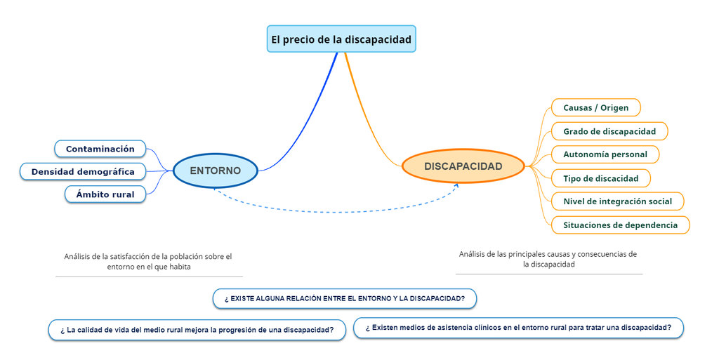

## Objetivos:

Teniendo en cuenta las secciones que trataremos, previamente descritas en la introducción, vamos a enumerar los objetivos del trabajo.

- Conocer cuáles son las causas más comunes de que aparezca una discapacidad.
- Analizar qué causas están relacionadas con el entorno en el que habita el discapacitado.
- Estudiar el efecto que tiene la contaminación en la aparición de ciertas minusvalías.
- Analizar el efecto que tiene la densidad demográfica y el ajetreo del medio urbano en la aparición de ciertas minusvalías.
- Comparar las características del medio rural y el medio urbano, y determinar qué ámbito es mejor para prevenir la aparición de minusvalías.
- Analizar el nivel de satisfacción de la sociedad con el entorno en que vive.
- Estudiar el grado de minusvalía y autonomía personal de la mayor parte de los discapacitados.
- Estudiar el nivel de integración social de los minusválidos en la sociedad actual.
- Analizar los medios clínicos disponibles para los discapacitados en los pueblos y en las ciudades.
- Analizar los problemas económicos discapacitados y las características de sus cuidadores.
- Determinar si la calidad de vida del medio rural mejora la progresión de una discapacidad.
- Reflexionar sobre la relación que existe entre la discapacidad y el entorno en el que vive el discapacitado.

## Metodología:

- El formato de todos los sets de datos con los que vamos a trabajar tienen la extensión “.xlsx” que es la extensión propia de Excel.
- Todos los datos los hemos cogido de páginas oficiales como la página del Instituto Nacional de Estadística y la página de datos del Gobierno de España.
- Los ficheros que vamos a trabajar son:
  - [Indicadores de la calidad de vida](https://www.ine.es/ss/Satellite?L=es_ES&c=INEPublicacion_C&cid=1259937499084&p=1254735110672&pagename=ProductosYServicios%2FPYSLayout&param1=PYSDetalleGratuitas&param2=1259944522559&param4=Mostrar#top/)
  - [Encuesta de Discapacidad, Autonomía Personal y Situaciones de Dependencia](https://datos.gob.es/es/catalogo/ea0010587-encuesta-de-discapacidad-autonomia-personal-y-situaciones-de-dependencia/).
  - [Encuesta de Integración Social y Salud](https://datos.gob.es/es/catalogo/ea0010587-encuesta-de-integracion-social-y-salud/).
  - [Encuestas sobre Discapacidades. Microdatos](https://datos.gob.es/es/catalogo/ea0010587-encuestas-sobre-discapacidades-microdatos4/).
- El tratamiento de datos lo llevaremos a cabo a través de gráficas y funciones estadísticas tales como *mean()*, *sd()*,*median()* o *summary()*

## Aclaración:

Antes de emprender el desarrollo del trabajo queremos hacer una aclaración con respecto a la terminología que vamos a emplear a continuación. Aunque comprobaréis que hemos utilizado continuamente la palabra “discapacitados”; desde nuestra posición, queremos unirnos a la campaña iniciada por la Convención Internacional por los Derechos de las Personas con Discapacidad de Naciones Unidas (ONU) donde se ha dispuesto que el término adecuado para tratar a este grupo de la población es **Personas en Situación de Discapacidad**.

Actualmente se ha determinado que la discapacidad es una cuestión de **Derechos Humanos** y no solo de salud o rehabilitación. Así que creemos que es preferible nombrar a estos individuos desde una visión positiva para no caer en eufemismos. Al fin y al cabo una persona con discapacidad **NO es un individuo incapacitado**, simplemente existen **barreras en el entorno que dificultan su vida cotidiana**. Cualquiera de nosotros puede tener otros problemas que no han sido típicamente etiquetados como “discapacidad” pero que implican impedimentos diariamente.

Así que aunque hemos empleado la palabra “discapacitados” por comodidad, no estamos del todo de acuerdo con su connotación, porque no debemos olvidar que **nadie es más válido que otra persona**.

[figure not shown]